# Lab Assignment Four: Multi-Layer Perceptron

##### Authors: Sian Xiao & Tingting Zhao

## 1. Load, Split, and Balance

**In this section, we will load the data and do some pre-processing.**

### 1.1 Loading data

```python
import os
import sys
import warnings

import matplotlib.pyplot as plt
import matplotlib.ticker as ticker
import numpy as np
import pandas as pd

from scipy.special import expit
from sklearn.metrics import accuracy_score
from sklearn.model_selection import train_test_split
from sklearn.preprocessing import LabelEncoder, StandardScaler
%matplotlib inline
# ignore warnings
warnings.simplefilter('ignore')
```

[output not shown]

```python
# load data
data = pd.read_csv('acs2017_census_tract_data.csv')
print(data.shape)
```

```
(74001, 37)
```

```python
# delete missing and duplicated data
data = data.dropna()
data = data.drop_duplicates()
print(data.shape)
```

```
(72718, 37)
```

```python
# drop columns 'TractId' and 'County'
data.drop(columns=['TractId', 'County'], inplace=True)
data.head()
```

|  | State | TotalPop | Men | Women | Hispanic | White | Black | Native | Asian | Pacific | ... | Walk | OtherTransp | WorkAtHome | MeanCommute | Employed | PrivateWork | PublicWork | SelfEmployed | FamilyWork | Unemployment |
| --- | --- | --- | --- | --- | --- | --- | --- | --- | --- | --- | --- | --- | --- | --- | --- | --- | --- | --- | --- | --- | --- |
| 0 | Alabama | 1845 | 899 | 946 | 2.4 | 86.3 | 5.2 | 0.0 | 1.2 | 0.0 | ... | 0.5 | 0.0 | 2.1 | 24.5 | 881 | 74.2 | 21.2 | 4.5 | 0.0 | 4.6 |
| 1 | Alabama | 2172 | 1167 | 1005 | 1.1 | 41.6 | 54.5 | 0.0 | 1.0 | 0.0 | ... | 0.0 | 0.5 | 0.0 | 22.2 | 852 | 75.9 | 15.0 | 9.0 | 0.0 | 3.4 |
| 2 | Alabama | 3385 | 1533 | 1852 | 8.0 | 61.4 | 26.5 | 0.6 | 0.7 | 0.4 | ... | 1.0 | 0.8 | 1.5 | 23.1 | 1482 | 73.3 | 21.1 | 4.8 | 0.7 | 4.7 |
| 3 | Alabama | 4267 | 2001 | 2266 | 9.6 | 80.3 | 7.1 | 0.5 | 0.2 | 0.0 | ... | 1.5 | 2.9 | 2.1 | 25.9 | 1849 | 75.8 | 19.7 | 4.5 | 0.0 | 6.1 |
| 4 | Alabama | 9965 | 5054 | 4911 | 0.9 | 77.5 | 16.4 | 0.0 | 3.1 | 0.0 | ... | 0.8 | 0.3 | 0.7 | 21.0 | 4787 | 71.4 | 24.1 | 4.5 | 0.0 | 2.3 |

5 rows × 35 columns

```python
# Encode string data 'State'
tmp = LabelEncoder().fit_transform(data['State'])
data['State'] = tmp
data.info()
```

```
<class 'pandas.core.frame.DataFrame'>
Int64Index: 72718 entries, 0 to 74000
Data columns (total 35 columns):
State               72718 non-null int64
TotalPop            72718 non-null int64
Men                 72718 non-null int64
Women               72718 non-null int64
Hispanic            72718 non-null float64
White               72718 non-null float64
Black               72718 non-null float64
Native              72718 non-null float64
Asian               72718 non-null float64
Pacific             72718 non-null float64
VotingAgeCitizen    72718 non-null int64
Income              72718 non-null float64
IncomeErr           72718 non-null float64
IncomePerCap        72718 non-null float64
IncomePerCapErr     72718 non-null float64
Poverty             72718 non-null float64
ChildPoverty        72718 non-null float64
Professional        72718 non-null float64
Service             72718 non-null float64
Office              72718 non-null float64
Construction        72718 non-null float64
Production          72718 non-null float64
Drive               72718 non-null float64
Carpool             72718 non-null float64
Transit             72718 non-null float64
Walk                72718 non-null float64
OtherTransp         72718 non-null float64
WorkAtHome          72718 non-null float64
MeanCommute         72718 non-null float64
Employed            72718 non-null int64
PrivateWork         72718 non-null float64
PublicWork          72718 non-null float64
SelfEmployed        72718 non-null float64
FamilyWork          72718 non-null float64
Unemployment        72718 non-null float64
dtypes: float64(29), int64(6)
memory usage: 20.0 MB
```

### 1.2 Split dataset

```python
# Split dataset by 80/20
X = data.drop("ChildPoverty", axis=1).to_numpy()
y_ori = data["ChildPoverty"].values
X_train, X_test, y_train_ori, y_test_ori = train_test_split(
    X, y_ori, test_size=0.2, random_state=42)
print(X_train.shape, X_test.shape, y_train_ori.shape, y_test_ori.shape)
```

```
(58174, 34) (14544, 34) (58174,) (14544,)
```

### 1.3 Balance the dataset

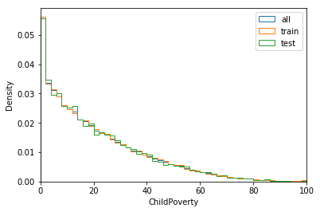

```python
# plot the distribution of 'ChildPoverty'
f, ax = plt.subplots()
ax.hist(y_ori, bins=50, density=True, histtype="step", label='all')
ax.hist(y_train_ori, bins=50, density=True, histtype="step", label='train')
ax.hist(y_test_ori, bins=50, density=True, histtype="step", label="test")
ax.set_xlim(0, 100)
plt.legend()
plt.xlabel("ChildPoverty")
plt.ylabel("Density")
plt.show()
```

Here we balance the dataset so that about the same number of instances are within each class.

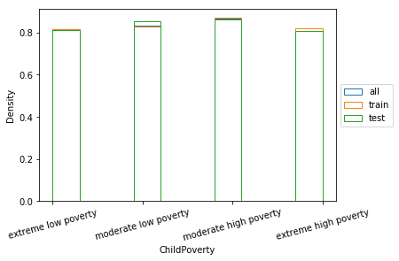

```python
# convert  regression to four levels of classification
def convert_to_four_class(arr_origin: np.ndarray) -> np.ndarray:
    # This is an in place operation, so make a copy first (otherwise, we can't tune the numbers).
    arr = arr_origin.copy()
    arr[arr <= 6] = 0
    arr[np.where((arr <= 16) & (arr > 6))[0]] = 1
    arr[np.where((arr <= 32) & (arr > 16))[0]] = 2
    arr[arr > 32] = 3
    return arr.astype(int)

y_ = convert_to_four_class(y_ori)
y_train_ = convert_to_four_class(y_train_ori)
y_test_ = convert_to_four_class(y_test_ori)


f, ax = plt.subplots()
ax.hist(y_, density=True, histtype="step", label="all")
ax.hist(y_train_, density=True, histtype="step", label='train')
ax.hist(y_test_, density=True, histtype="step", label="test")
plt.legend(loc='center left', bbox_to_anchor=(1, 0.5))
plt.xticks(range(4), ('extreme low poverty', 'moderate low poverty','moderate high poverty','extreme high poverty'),rotation = 15)
plt.xlabel("ChildPoverty")
plt.ylabel("Density")
plt.show()
```

**As we can see, both test set and train set are balanced.**

**In my opinion, the balancing should be done for both training and testing set (in a same criteria). We don't want instance with same values be classified into different classes.**

```python
#one hot code target
y_train = pd.get_dummies(y_train_).values
y_test = pd.get_dummies(y_test_).values
print(y_train.shape, y_test.shape)
```

```
(58174, 4) (14544, 4)
```

## 2. Pre-processing

**In this section, we will implement two-layer perceptron network and and quantify performance using accuracy.**

### 2.1 Model 1

```python
# two layer perceptron with vectorized computation, mini-batching and Glorot initialization
# delete _encode_labels(y) because we already one-hot encoded target
class TwoLP():
    def __init__(self, n_hidden=30, C=0.0, epochs=500, eta=0.001, random_state=None,
                 alpha=0.1, decrease_const=0.0, shuffle=True, minibatches=1):
        np.random.seed(random_state)
        self.n_hidden = n_hidden
        self.l2_C = C
        self.epochs = epochs
        self.eta = eta
        self.alpha = alpha
        self.decrease_const = decrease_const
        self.shuffle = shuffle
        self.minibatches = minibatches

    def _initialize_weights(self):
        """Initialize weights Glorot and He normalization"""

        init_bound = 4 * np.sqrt(6 / (self.n_hidden + self.n_features_ + 1))
        W1 = np.random.uniform(-init_bound, init_bound,
                               (self.n_hidden, self.n_features_ + 1))
        W1[:, :1] = 0

        init_bound = 4 * np.sqrt(6 / (self.n_output_ + self.n_hidden + 1))
        W2 = np.random.uniform(-init_bound, init_bound,
                               (self.n_output_, self.n_hidden + 1))
        W2[:, :1] = 0
        return W1, W2

    @staticmethod
    def _sigmoid(z):
        """Use scipy.special.expit to avoid overflow"""

        return expit(z)

    @staticmethod
    def _add_bias_unit(X, how='column'):
        """Add bias unit (column or row of 1s) to array at index 0"""

        if how == 'column':
            ones = np.ones((X.shape[0], 1))
            X_new = np.hstack((ones, X))
        elif how == 'row':
            ones = np.ones((1, X.shape[1]))
            X_new = np.vstack((ones, X))

        return X_new

    @staticmethod
    def _L2_reg(lambda_, W1, W2):
        """Compute L2-regularization cost for non-bias terms"""

        return (lambda_/2.0) * np.sqrt(np.mean(W1[:, 1:] ** 2) + np.mean(W2[:, 1:] ** 2))

    def _cost(self, A3, Y_enc, W1, W2):
        '''Get the objective function value'''

        cost = np.mean((Y_enc-A3)**2)
        L2_term = self._L2_reg(self.l2_C, W1, W2)

        return cost + L2_term

    def _feedforward(self, X, W1, W2):
        """Compute feedforward step
        -----------
        X: Input layer with original features
        W: Weight matrix between layers
        A: Activations into layer (or output layer)
        Z: Layer inputs
        """

        A1 = self._add_bias_unit(X.T, how='row')
        Z1 = W1 @ A1
        A2 = self._sigmoid(Z1)
        A2 = self._add_bias_unit(A2, how='row')
        Z2 = W2 @ A2
        A3 = self._sigmoid(Z2)

        return A1, Z1, A2, Z2, A3

    def _get_gradient(self, A1, A2, A3, Z1, Z2, Y_enc, W1, W2):
        """ Compute gradient step using backpropagation"""

        # vectorized backpropagation
        V2 = -2*(Y_enc-A3)*A3*(1-A3)
        V1 = A2*(1-A2)*(W2.T @ V2)
        grad2 = V2 @ A2.T
        grad1 = V1[1:, :] @ A1.T

        # regularize weights that are not bias terms
        grad1[:, 1:] += W1[:, 1:] * self.l2_C
        grad2[:, 1:] += W2[:, 1:] * self.l2_C

        return grad1, grad2

    def predict(self, X):
        """Predict class labels"""
        _, _, _, _, A3 = self._feedforward(X, self.W1, self.W2)
        y_pred = np.argmax(A3, axis=0)
        return y_pred

    # mini-batching
    def fit(self, X, y, print_progress=0):
        """ Learn weights from training data."""

        X_data, y_data = X.copy(), y.copy()
        # y already be one-hot encoded
        Y_enc = np.transpose(y)

        # init weights and setup matrices
        self.n_features_ = X_data.shape[1]
        self.n_output_ = Y_enc.shape[0]
        self.W1, self.W2 = self._initialize_weights()

        # start momentum at zero for previous updates
        rho_W1_prev = np.zeros(self.W1.shape)  # for momentum
        rho_W2_prev = np.zeros(self.W2.shape)  # for momentum
        self.grad_w1_ = []
        self.grad_w2_ = []
        self.cost_ = []

        for k in range(self.epochs):
            # adaptive learning rate
            eta = self.eta ** (1 + self.decrease_const * k)
            eta = max(eta, self.eta / 1000)

            if print_progress > 0 and (k+1) % print_progress == 0:
                sys.stderr.write('\rEpoch: %d/%d' % (k+1, self.epochs))
                sys.stderr.flush()

            if self.shuffle:
                ridx = np.random.permutation(y_data.shape[0])
                X_data, Y_enc = X_data[ridx], Y_enc[:, ridx]

            # use numpy split to split into equal sized batches
            # num batches == self.minibatches
            mini = np.array_split(range(y_data.shape[0]), self.minibatches)
            mini_cost = []
            grad1s = []
            grad2s = []
            for idx in mini:

                # feedforward
                A1, Z1, A2, Z2, A3 = self._feedforward(X_data[idx],
                                                       self.W1,
                                                       self.W2)

                cost = self._cost(A3, Y_enc[:, idx], self.W1, self.W2)
                mini_cost.append(cost)  # this appends cost of mini-batch only

                # compute gradient via backpropagation
                grad1, grad2 = self._get_gradient(A1=A1, A2=A2, A3=A3, Z1=Z1, Z2=Z2,
                                                  Y_enc=Y_enc[:, idx],
                                                  W1=self.W1, W2=self.W2)
                grad1s.append(np.mean(np.abs(grad1)))
                grad2s.append(np.mean(np.abs(grad2)))

                rho_W1, rho_W2 = eta * grad1, eta * grad2
                # update with momentum
                self.W1 -= (rho_W1 + (self.alpha * rho_W1_prev))
                # update with momentum
                self.W2 -= (rho_W2 + (self.alpha * rho_W2_prev))
                rho_W1_prev, rho_W2_prev = rho_W1, rho_W2
            self.grad_w1_.append(np.mean(np.abs(grad1s)))
            self.grad_w2_.append(np.mean(np.abs(grad2s)))
            self.cost_.append(mini_cost)

        return self
```

```python
# set parameters for model training
params = dict(n_hidden=50,
              C=0.1,               # tradeoff L2 regularizer
              epochs=1000,         # iterations
              eta=0.01,            # learning rate
              random_state=1,
              alpha=0.01,          # momentum calculation
              decrease_const=0.1,  # decreasing eta
              minibatches=250,     # minibatch size
              shuffle=True)
```

```
Epoch: 1000/1000
```

```
Accuracy: 0.26134488448844884
```

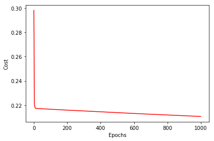

```
CPU times: user 1h 7min 5s, sys: 52min 12s, total: 1h 59min 17s
Wall time: 3min 19s
```

```python
%%time
model_1 = TwoLP(**params)
model_1.fit(X_train, y_train, print_progress=50)

yhat1 = model_1.predict(X_test)
print('Accuracy:', accuracy_score(np.argmax(y_test, axis=1), yhat1))

# take the mean of each minibatch epoch
cost_avgs = [np.mean(x) for x in model_1.cost_]

plt.plot(range(len(cost_avgs)), cost_avgs, color='red')
plt.ylabel('Cost')
plt.xlabel('Epochs')
plt.tight_layout()
plt.show()
```

### 2.2 Model 2

```
Epoch: 1000/1000
```

```
Accuracy: 0.7033140814081408
```

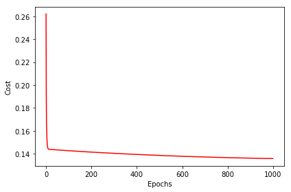

```python
# Only normalize the continuous numeric feature data, excluding 'State'

norm = StandardScaler()
X_train_num_scaled = norm.fit_transform(np.delete(X_train, 0, 1))  # only fit training set
X_test_num_scaled = norm.transform(np.delete(X_test, 0, 1))  # transform testing set
X_train_scaled = np.hstack((X_train_num_scaled, X_train[:, 0].reshape(-1, 1)))
X_test_scaled = np.hstack((X_test_num_scaled, X_test[:, 0].reshape(-1, 1)))

model_2 = TwoLP(**params)
model_2.fit(X_train_scaled, y_train, print_progress=50)

yhat2 = model_2.predict(X_test_scaled)
print('Accuracy:', accuracy_score(np.argmax(y_test, axis=1), yhat2))

# take the mean of each minibatch epoch
cost_avgs = [np.mean(x) for x in model_2.cost_]

plt.plot(range(len(cost_avgs)), cost_avgs, color='red')
plt.ylabel('Cost')
plt.xlabel('Epochs')
plt.tight_layout()
plt.show()
```

### 2.3 Model 3

```
Make sure training set and testing set have all the states
[ True  True  True  True  True  True  True  True  True  True  True  True
  True  True  True  True  True  True  True  True  True  True  True  True
  True  True  True  True  True  True  True  True  True  True  True  True
  True  True  True  True  True  True  True  True  True  True  True  True
  True  True  True  True]
52
(58174, 85)
(14544, 85)
```

```
Epoch: 1000/1000
```

```
Accuracy: 0.7170654565456546
```

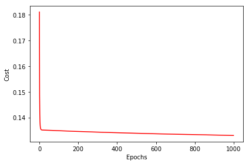

```python
# Normalize the continuous numeric feature data AND one hot encode the categorical data

norm = StandardScaler()
X_train_num_scaled = norm.fit_transform(np.delete(X_train, 0, 1))
X_test_num_scaled = norm.transform(np.delete(X_test, 0, 1))

# confirm training set and testing set have all the states, then we can one-hot encode them
print("Make sure training set and testing set have all the states")
print(np.unique(X_train[:, 0])==np.unique(X_test[:, 0]))
print(len(np.unique(X_train[:, 0])))

train_one_hot_state = pd.get_dummies(X_train[:, 0]).values
X_train_scaled_coded = np.hstack((X_train_num_scaled, train_one_hot_state))
print(X_train_scaled_coded.shape)

test_one_hot_state = pd.get_dummies(X_test[:, 0]).values
X_test_scaled_coded = np.hstack((X_test_num_scaled, test_one_hot_state))
print(X_test_scaled_coded.shape)

model_3 = TwoLP(**params)
model_3.fit(X_train_scaled_coded, y_train, print_progress=50)

yhat3 = model_3.predict(X_test_scaled_coded)
print('Accuracy:', accuracy_score(np.argmax(y_test, axis=1), yhat3))

# take the mean of each minibatch epoch
cost_avgs = [np.mean(x) for x in model_3.cost_]

plt.plot(range(len(cost_avgs)), cost_avgs, color='red')
plt.ylabel('Cost')
plt.xlabel('Epochs')
plt.tight_layout()
plt.show()
```

### 2.4 Compare the performance of the three models.

**McNemar's Testing**

$$\chi^2 = \frac{(|B-C|^2)}{B+C}$$

| Confidence | 0.90 | 0.95 | 0.99 |
| --- | --- | --- | --- |
| Critical Value | 2.706 | 3.841 | 6.635 |

```python
# Define a function for McNemar's Test
# confidence:           0.90  0.95  0.99
# 1DOF critical value: 2.706 3.841 6.635

def mn_test(ypred1, ypred2, ytrue):
    tab_b = sum((ypred1 == ytrue) & (ypred2 != ytrue))
    tab_c = sum((ypred1 != ytrue) & (ypred2 == ytrue))

    if tab_b + tab_c == 0:
        chi2 = 0
    else:
        chi2 = (abs(tab_b - tab_c)-1)**2 / (tab_b + tab_c)

    return chi2

M12 = mn_test(yhat1, yhat2, np.argmax(y_test, axis=1))
M13 = mn_test(yhat1, yhat3, np.argmax(y_test, axis=1))
M23 = mn_test(yhat2, yhat3, np.argmax(y_test, axis=1))
print(f'Model 1 vs Model 2: Test statistic = {M12}.')
print(f'Model 1 vs Model 3: Test statistic = {M13}.')
print(f'Model 2 vs Model 3: Test statistic = {M23}.')
```

```
Model 1 vs Model 2: Test statistic = 4781.932044454735.
Model 1 vs Model 3: Test statistic = 4913.529760572835.
Model 2 vs Model 3: Test statistic = 42.49034334763949.
```

**Since the dataset is well balanced, so accuracy score is good enough to evaluate the model performance.**

| Model | 1 | 2 | 3 |
| --- | --- | --- | --- |
| Accuracy | 26.13% | 70.33% | 71.71% |

**Since all the $\chi^2$ statistic values are much larger than 6.635, we can reject the null hypothesis, which means the three model are significantly different from each other. So we can conclude with 0.99 confidence that Model 3 has the best performance with accuracy 71.71%.**

## 3. Modeling

### 3.1 Three-layer Perceptron

```python
class ThreeLP():
    def __init__(self, n_hidden=30, C=0.0, epochs=500, eta=0.001, random_state=None,
                 alpha=0.1, decrease_const=0.0, shuffle=True, minibatches=1):
        np.random.seed(random_state)
        self.n_hidden = n_hidden
        self.l2_C = C
        self.epochs = epochs
        self.eta = eta
        self.alpha = alpha
        self.decrease_const = decrease_const
        self.shuffle = shuffle
        self.minibatches = minibatches

    def _initialize_weights(self):
        init_bound = 4 * np.sqrt(6 / (self.n_hidden + self.n_features_ + 1))
        W1 = np.random.uniform(-init_bound, init_bound,
                               (self.n_hidden, self.n_features_ + 1))
        W1[:, :1] = 0

        init_bound = 4 * np.sqrt(6 / (self.n_hidden + self.n_hidden + 1))
        W2 = np.random.uniform(-init_bound, init_bound,
                               (self.n_hidden, self.n_hidden + 1))
        W2[:, :1] = 0

        init_bound = 4 * np.sqrt(6 / (self.n_output_ + self.n_hidden + 1))
        W3 = np.random.uniform(-init_bound, init_bound,
                               (self.n_output_, self.n_hidden + 1))
        W3[:, :1] = 0

        return W1, W2, W3

    @staticmethod
    def _sigmoid(z):
        return expit(z)

    @staticmethod
    def _add_bias_unit(X, how='column'):
        if how == 'column':
            ones = np.ones((X.shape[0], 1))
            X_new = np.hstack((ones, X))
        elif how == 'row':
            ones = np.ones((1, X.shape[1]))
            X_new = np.vstack((ones, X))

        return X_new

    @staticmethod
    def _L2_reg(lambda_, W1, W2, W3):
        return (lambda_/2.0) * np.sqrt(np.mean(W1[:, 1:] ** 2) + np.mean(W2[:, 1:] ** 2) + np.mean(W3[:, 1:] ** 2))

    def _cost(self, A4, Y_enc, W1, W2, W3):
        cost = np.mean((Y_enc-A4)**2)
        L2_term = self._L2_reg(self.l2_C, W1, W2, W3)

        return cost + L2_term

    def _feedforward(self, X, W1, W2, W3):
        A1 = self._add_bias_unit(X.T, how='row')
        Z1 = W1 @ A1
        A2 = self._sigmoid(Z1)
        A2 = self._add_bias_unit(A2, how='row')
        Z2 = W2 @ A2
        A3 = self._sigmoid(Z2)
        A3 = self._add_bias_unit(A3, how='row')
        Z3 = W3 @ A3
        A4 = self._sigmoid(Z3)

        return A1, Z1, A2, Z2, A3, Z3, A4

    def _get_gradient(self, A1, A2, A3, A4, Z1, Z2, Z3, Y_enc, W1, W2, W3):
        V3 = -2*(Y_enc-A4)*A4*(1-A4)
        V2 = A3*(1-A3)*(W3.T @ V3)
        V1 = A2*(1-A2)*(W2.T @ V2[1:, :])

        grad3 = V3 @ A3.T
        grad2 = V2[1:, :] @ A2.T
        grad1 = V1[1:, :] @ A1.T

        grad1[:, 1:] += W1[:, 1:] * self.l2_C
        grad2[:, 1:] += W2[:, 1:] * self.l2_C
        grad3[:, 1:] += W3[:, 1:] * self.l2_C

        return grad1, grad2, grad3

    def predict(self, X):
        _, _, _, _, _, _, A4 = self._feedforward(X, self.W1, self.W2, self.W3)
        y_pred = np.argmax(A4, axis=0)

        return y_pred

    def fit(self, X, y, print_progress=0):
        X_data, y_data = X.copy(), y.copy()
        Y_enc = np.transpose(y)

        self.n_features_ = X_data.shape[1]
        self.n_output_ = Y_enc.shape[0]
        self.W1, self.W2, self.W3 = self._initialize_weights()

        rho_W1_prev = np.zeros(self.W1.shape)
        rho_W2_prev = np.zeros(self.W2.shape)
        rho_W3_prev = np.zeros(self.W3.shape)
        self.grad_w1_ = []
        self.grad_w2_ = []
        self.grad_w3_ = []
        self.cost_ = []
        for k in range(self.epochs):
            eta = self.eta ** (1 + self.decrease_const * k)
            eta = max(eta, self.eta / 1000)

            if print_progress > 0 and (k+1) % print_progress == 0:
                sys.stderr.write('\rEpoch: %d/%d' % (k+1, self.epochs))
                sys.stderr.flush()

            if self.shuffle:
                ridx = np.random.permutation(y_data.shape[0])
                X_data, Y_enc = X_data[ridx], Y_enc[:, ridx]

            mini = np.array_split(range(y_data.shape[0]), self.minibatches)
            mini_cost = []
            grad1s, grad2s, grad3s = [], [], []

            for idx in mini:
                A1, Z1, A2, Z2, A3, Z3, A4 = self._feedforward(
                    X_data[idx], self.W1, self.W2, self.W3)
                cost = self._cost(A4, Y_enc[:, idx], self.W1, self.W2, self.W3)
                mini_cost.append(cost)

                grad1, grad2, grad3 = self._get_gradient(A1=A1, A2=A2, A3=A3, A4=A4, Z1=Z1, Z2=Z2, Z3=Z3,
                                                         Y_enc=Y_enc[:, idx], W1=self.W1, W2=self.W2, W3=self.W3)
                grad1s.append(np.mean(np.abs(grad1)))
                grad2s.append(np.mean(np.abs(grad2)))
                grad3s.append(np.mean(np.abs(grad3)))

                rho_W1, rho_W2, rho_W3 = eta * grad1, eta * grad2, eta * grad3

                self.W1 -= (rho_W1 + (self.alpha * rho_W1_prev))
                self.W2 -= (rho_W2 + (self.alpha * rho_W2_prev))
                self.W3 -= (rho_W3 + (self.alpha * rho_W3_prev))

                rho_W1_prev, rho_W2_prev, rho_W3_preV = rho_W1, rho_W2, rho_W3

            self.grad_w1_.append(np.mean(np.abs(grad1s)))
            self.grad_w2_.append(np.mean(np.abs(grad2s)))
            self.grad_w3_.append(np.mean(np.abs(grad3s)))
            self.cost_.append(mini_cost)
        return self
```

```
Epoch: 1000/1000
```

```
Accuracy: 0.7275852585258525
```

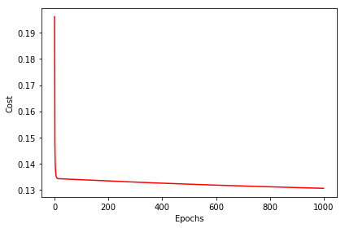

```python
model_three = ThreeLP(**params)
model_three.fit(X_train_scaled_coded, y_train, print_progress=50)

yhat_3 = model_three.predict(X_test_scaled_coded)
print('Accuracy:', accuracy_score(np.argmax(y_test, axis=1), yhat_3))

cost_avgs = [np.mean(x) for x in model_three.cost_]

plt.plot(range(len(cost_avgs)), cost_avgs, color='red')
plt.ylabel('Cost')
plt.xlabel('Epochs')
plt.tight_layout()
plt.show()
```

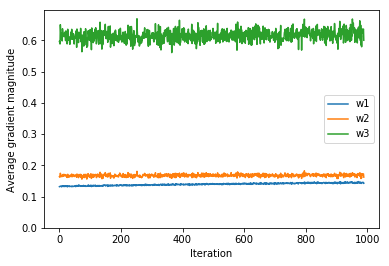

```python
ax = plt.subplot(1, 1, 1)
plt.plot(np.absolute(model_three.grad_w1_[10:]), label='w1')
plt.plot(np.absolute(model_three.grad_w2_[10:]), label='w2')
plt.plot(np.absolute(model_three.grad_w3_[10:]), label='w3')
plt.legend()
plt.ylim(0)
plt.ylabel('Average gradient magnitude')
plt.xlabel('Iteration')
plt.show()
```

```python
M = mn_test(yhat_3, yhat3, np.argmax(y_test, axis=1))
print(f'Three layer vs two layer: Test statistic = {M}.')
```

```
Three layer vs two layer: Test statistic = 33.926578560939795.
```

| Layer | 2 | 3 |
| --- | --- | --- |
| Accuracy | 71.71% | 72.76% |

**With three layer perceptron, the accuracy is around 72.76%, since the test statistic is larger than 6.635, we can conclude that it is better than two layer perceptron.**

**The plot of average agradient magnitude obviously shows the gradient vanishing issue.**

### 3.2 Four-layer Perceptron

```python
class FourLP():
    def __init__(self, n_hidden=30, C=0.0, epochs=500, eta=0.001, random_state=None,
                 alpha=0.1, decrease_const=0.0, shuffle=True, minibatches=1):
        np.random.seed(random_state)
        self.n_hidden = n_hidden
        self.l2_C = C
        self.epochs = epochs
        self.eta = eta
        self.alpha = alpha
        self.decrease_const = decrease_const
        self.shuffle = shuffle
        self.minibatches = minibatches

    def _initialize_weights(self):
        init_bound = 4*np.sqrt(6 / (self.n_hidden + self.n_features_ + 1))
        W1 = np.random.uniform(-init_bound, init_bound,
                               (self.n_hidden, self.n_features_ + 1))
        W1[:, :1] = 0

        init_bound = 4*np.sqrt(6 / (self.n_hidden + self.n_hidden + 1))
        W2 = np.random.uniform(-init_bound, init_bound,
                               (self.n_hidden, self.n_hidden + 1))
        W2[:, :1] = 0

        init_bound = 4 * np.sqrt(6 / (self.n_hidden + self.n_hidden + 1))
        W3 = np.random.uniform(-init_bound, init_bound,
                               (self.n_hidden, self.n_hidden + 1))
        W3[:, :1] = 0

        init_bound = 4 * np.sqrt(6 / (self.n_output_ + self.n_hidden + 1))
        W4 = np.random.uniform(-init_bound, init_bound,
                               (self.n_output_, self.n_hidden + 1))
        W4[:, :1] = 0

        return W1, W2, W3, W4

    @staticmethod
    def _sigmoid(z):
        return expit(z)

    @staticmethod
    def _add_bias_unit(X, how='column'):
        if how == 'column':
            ones = np.ones((X.shape[0], 1))
            X_new = np.hstack((ones, X))
        elif how == 'row':
            ones = np.ones((1, X.shape[1]))
            X_new = np.vstack((ones, X))

        return X_new

    @staticmethod
    def _L2_reg(lambda_, W1, W2, W3, W4):
        return (lambda_/2.0) * np.sqrt(np.mean(W1[:, 1:] ** 2) + np.mean(W2[:, 1:] ** 2) + np.mean(W3[:, 1:] ** 2) + np.mean(W4[:, 1:] ** 2))

    def _cost(self, A5, Y_enc, W1, W2, W3, W4):
        cost = np.mean((Y_enc-A5)**2)
        L2_term = self._L2_reg(self.l2_C, W1, W2, W3, W4)

        return cost + L2_term

    def _feedforward(self, X, W1, W2, W3, W4):
        A1 = self._add_bias_unit(X.T, how='row')
        Z1 = W1 @ A1
        A2 = self._sigmoid(Z1)
        A2 = self._add_bias_unit(A2, how='row')
        Z2 = W2 @ A2
        A3 = self._sigmoid(Z2)
        A3 = self._add_bias_unit(A3, how='row')
        Z3 = W3 @ A3  # !added
        A4 = self._sigmoid(Z3)
        A4 = self._add_bias_unit(A4, how='row')
        Z4 = W4 @ A4
        A5 = self._sigmoid(Z4)

        return A1, Z1, A2, Z2, A3, Z3, A4, Z4, A5

    def _get_gradient(self, A1, A2, A3, A4, A5, Z1, Z2, Z3, Z4, Y_enc, W1, W2, W3, W4):
        V4 = -2*(Y_enc-A5)*A5*(1-A5)
        V3 = A4*(1-A4)*(W4.T @ V4)
        V2 = A3*(1-A3)*(W3.T @ V3[1:, :])
        V1 = A2*(1-A2)*(W2.T @ V2[1:, :])

        grad4 = V4 @ A4.T
        grad3 = V3[1:, :] @ A3.T
        grad2 = V2[1:, :] @ A2.T
        grad1 = V1[1:, :] @ A1.T

        grad1[:, 1:] += W1[:, 1:] * self.l2_C
        grad2[:, 1:] += W2[:, 1:] * self.l2_C
        grad3[:, 1:] += W3[:, 1:] * self.l2_C
        grad4[:, 1:] += W4[:, 1:] * self.l2_C

        return grad1, grad2, grad3, grad4

    def predict(self, X):
        _, _, _, _, _, _, _, _, A5 = self._feedforward(
            X, self.W1, self.W2, self.W3, self.W4)
        y_pred = np.argmax(A5, axis=0)

        return y_pred

    def fit(self, X, y, print_progress=0):
        X_data, y_data = X.copy(), y.copy()
        Y_enc = np.transpose(y)
        print("Y_enc", Y_enc.shape)

        self.n_features_ = X_data.shape[1]
        self.n_output_ = Y_enc.shape[0]
        print("self.n_output_", self.n_output_)
        self.W1, self.W2, self.W3, self.W4 = self._initialize_weights()

        rho_W1_prev = np.zeros(self.W1.shape)
        rho_W2_prev = np.zeros(self.W2.shape)
        rho_W3_prev = np.zeros(self.W3.shape)
        rho_W4_prev = np.zeros(self.W4.shape)
        self.grad_w1_, self.grad_w2_, self.grad_w3_, self.grad_w4_ = [], [], [], []
        self.cost_ = []

        for k in range(self.epochs):
            eta = self.eta ** (1 + self.decrease_const * k)
            eta = max(eta, self.eta / 1000)

            if print_progress > 0 and (k+1) % print_progress == 0:
                sys.stderr.write('\rEpoch: %d/%d' % (k+1, self.epochs))
                sys.stderr.flush()

            if self.shuffle:
                ridx = np.random.permutation(y_data.shape[0])
                X_data, Y_enc = X_data[ridx], Y_enc[:, ridx]

            mini = np.array_split(range(y_data.shape[0]), self.minibatches)
            mini_cost = []

            grad1s, grad2s, grad3s, grad4s = [], [], [], []

            for idx in mini:
                A1, Z1, A2, Z2, A3, Z3, A4, Z4, A5 = self._feedforward(X_data[idx],
                                                                       self.W1,
                                                                       self.W2,
                                                                       self.W3,
                                                                       self.W4)
                cost = self._cost(
                    A5, Y_enc[:, idx], self.W1, self.W2, self.W3, self.W4)
                mini_cost.append(cost)

                grad1, grad2, grad3, grad4 = self._get_gradient(
                    A1=A1, A2=A2, A3=A3, A4=A4, A5=A5, Z1=Z1, Z2=Z2, Z3=Z3, Z4=Z4,
                    Y_enc=Y_enc[:, idx], W1=self.W1, W2=self.W2, W3=self.W3, W4=self.W4)
                grad1s.append(np.mean(np.abs(grad1)))
                grad2s.append(np.mean(np.abs(grad2)))
                grad3s.append(np.mean(np.abs(grad3)))
                grad4s.append(np.mean(np.abs(grad4)))

                rho_W1, rho_W2, rho_W3, rho_W4 = eta * \
                    grad1, eta * grad2, eta * grad3, eta * grad4

                self.W1 -= (rho_W1 + (self.alpha * rho_W1_prev))
                self.W2 -= (rho_W2 + (self.alpha * rho_W2_prev))
                self.W3 -= (rho_W3 + (self.alpha * rho_W3_prev))
                self.W4 -= (rho_W4 + (self.alpha * rho_W4_prev))
                rho_W1_prev, rho_W2_prev, rho_W3_preV, rho_W4_preV = rho_W1, rho_W2, rho_W3, rho_W4

            self.grad_w1_.append(np.mean(np.abs(grad1s)))
            self.grad_w2_.append(np.mean(np.abs(grad2s)))
            self.grad_w3_.append(np.mean(np.abs(grad3s)))
            self.grad_w4_.append(np.mean(np.abs(grad4s)))
            self.cost_.append(mini_cost)
        return self
```

```
Y_enc (4, 58174)
self.n_output_ 4
```

```
Epoch: 1000/1000
```

```
Accuracy: 0.7304730473047305
```

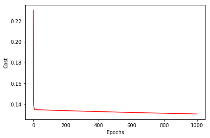

```python
model_four = FourLP(**params)
model_four.fit(X_train_scaled_coded, y_train, print_progress=50)

yhat_4 = model_four.predict(X_test_scaled_coded)
print('Accuracy:', accuracy_score(np.argmax(y_test, axis=1), yhat_4))

cost_avgs = [np.mean(x) for x in model_four.cost_]

plt.plot(range(len(cost_avgs)), cost_avgs, color='red')
plt.ylabel('Cost')
plt.xlabel('Epochs')
plt.tight_layout()
plt.show()
```

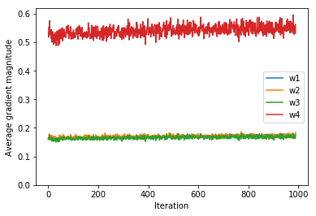

```python
ax = plt.subplot(1, 1, 1)
plt.plot(np.absolute(model_four.grad_w1_[10:]), label='w1')
plt.plot(np.absolute(model_four.grad_w2_[10:]), label='w2')
plt.plot(np.absolute(model_four.grad_w3_[10:]), label='w3')
plt.plot(np.absolute(model_four.grad_w4_[10:]), label='w4')
plt.legend()
plt.ylim(0)
plt.ylabel('Average gradient magnitude')
plt.xlabel('Iteration')
plt.show()
```

```python
M = mn_test(yhat_4, yhat_3, np.argmax(y_test, axis=1))
print(f'Four layer vs three layer: Test statistic = {M}.')
```

```
Four layer vs three layer: Test statistic = 5.717687074829932.
```

| Layer | 2 | 3 | 4 |
| --- | --- | --- | --- |
| Accuracy | 71.71% | 72.76% | 73.05% |

**With Four layer perceptron, the accuracy is around 73.05%, since the $\chi^2$ statistic value is between 3.841 and 6.635, we can conclude that it is better than three layer perceptron with 0.95 confidence.**

**The plot of average gradient magnitude obviously shows the gradient vanishing issue.**

### 3.3 Five-layer Perceptron

```python
class FiveLP():
    def __init__(self, n_hidden=30, C=0.0, epochs=500, eta=0.001, random_state=None,
                 alpha=0.1, decrease_const=0.0, shuffle=True, minibatches=1):
        np.random.seed(random_state)
        self.n_hidden = n_hidden
        self.l2_C = C
        self.epochs = epochs
        self.eta = eta
        self.alpha = alpha
        self.decrease_const = decrease_const
        self.shuffle = shuffle
        self.minibatches = minibatches

    def _initialize_weights(self):
        init_bound = 4 * np.sqrt(6 / (self.n_hidden + self.n_features_ + 1))
        W1 = np.random.uniform(-init_bound, init_bound,
                               (self.n_hidden, self.n_features_ + 1))
        W1[:, :1] = 0

        init_bound = 4 * np.sqrt(6 / (self.n_hidden + self.n_hidden + 1))
        W2 = np.random.uniform(-init_bound, init_bound,
                               (self.n_hidden, self.n_hidden + 1))
        W2[:, :1] = 0

        init_bound = 4 * np.sqrt(6 / (self.n_hidden + self.n_hidden + 1))
        W3 = np.random.uniform(-init_bound, init_bound,
                               (self.n_hidden, self.n_hidden + 1))
        W3[:, :1] = 0

        init_bound = 4 * np.sqrt(6 / (self.n_hidden + self.n_hidden + 1))
        W4 = np.random.uniform(-init_bound, init_bound,
                               (self.n_hidden, self.n_hidden + 1))
        W4[:, :1] = 0

        init_bound = 4 * np.sqrt(6 / (self.n_output_ + self.n_hidden + 1))
        W5 = np.random.uniform(-init_bound, init_bound,
                               (self.n_output_, self.n_hidden + 1))
        W5[:, :1] = 0

        return W1, W2, W3, W4, W5

    @staticmethod
    def _sigmoid(z):
        return expit(z)

    @staticmethod
    def _add_bias_unit(X, how='column'):
        if how == 'column':
            ones = np.ones((X.shape[0], 1))
            X_new = np.hstack((ones, X))
        elif how == 'row':
            ones = np.ones((1, X.shape[1]))
            X_new = np.vstack((ones, X))

        return X_new

    @staticmethod
    def _L2_reg(lambda_, W1, W2, W3, W4, W5):
        return (lambda_/2.0) * np.sqrt(np.mean(W1[:, 1:] ** 2) + np.mean(W2[:, 1:] ** 2) + np.mean(W3[:, 1:] ** 2) + np.mean(W4[:, 1:] ** 2) + np.mean(W5[:, 1:] ** 2))

    def _cost(self, A6, Y_enc, W1, W2, W3, W4, W5):
        cost = np.mean((Y_enc-A6)**2)
        L2_term = self._L2_reg(self.l2_C, W1, W2, W3, W4, W5)

        return cost + L2_term

    def _feedforward(self, X, W1, W2, W3, W4, W5):
        A1 = self._add_bias_unit(X.T, how='row')
        Z1 = W1 @ A1
        A2 = self._sigmoid(Z1)
        A2 = self._add_bias_unit(A2, how='row')
        Z2 = W2 @ A2
        A3 = self._sigmoid(Z2)
        A3 = self._add_bias_unit(A3, how='row')
        Z3 = W3 @ A3
        A4 = self._sigmoid(Z3)
        A4 = self._add_bias_unit(A4, how='row')
        Z4 = W4 @ A4
        A5 = self._sigmoid(Z4)
        A5 = self._add_bias_unit(A5, how='row')
        Z5 = W5 @ A5
        A6 = self._sigmoid(Z5)

        return A1, Z1, A2, Z2, A3, Z3, A4, Z4, A5, Z5, A6

    def _get_gradient(self, A1, A2, A3, A4, A5, A6, Z1, Z2, Z3, Z4, Z5, Y_enc, W1, W2, W3, W4, W5):
        V5 = -2*(Y_enc-A6)*A6*(1-A6)
        V4 = A5*(1-A5)*(W5.T @ V5)
        V3 = A4*(1-A4)*(W4.T @ V4[1:, :])
        V2 = A3*(1-A3)*(W3.T @ V3[1:, :])
        V1 = A2*(1-A2)*(W2.T @ V2[1:, :])

        grad5 = V5 @ A5.T
        grad4 = V4[1:, :] @ A4.T
        grad3 = V3[1:, :] @ A3.T
        grad2 = V2[1:, :] @ A2.T
        grad1 = V1[1:, :] @ A1.T

        grad1[:, 1:] += W1[:, 1:] * self.l2_C
        grad2[:, 1:] += W2[:, 1:] * self.l2_C
        grad3[:, 1:] += W3[:, 1:] * self.l2_C
        grad4[:, 1:] += W4[:, 1:] * self.l2_C
        grad5[:, 1:] += W5[:, 1:] * self.l2_C

        return grad1, grad2, grad3, grad4, grad5

    def predict(self, X):
        _, _, _, _, _, _, _, _, _, _, A6 = self._feedforward(
            X, self.W1, self.W2, self.W3, self.W4, self.W5)
        y_pred = np.argmax(A6, axis=0)
        return y_pred

    def fit(self, X, y, print_progress=0):
        X_data, y_data = X.copy(), y.copy()
        Y_enc = np.transpose(y)
        print("Y_enc", Y_enc.shape)

        self.n_features_ = X_data.shape[1]
        self.n_output_ = Y_enc.shape[0]
        print("self.n_output_", self.n_output_)
        self.W1, self.W2, self.W3, self.W4, self.W5 = self._initialize_weights()

        rho_W1_prev = np.zeros(self.W1.shape)
        rho_W2_prev = np.zeros(self.W2.shape)
        rho_W3_prev = np.zeros(self.W3.shape)
        rho_W4_prev = np.zeros(self.W4.shape)
        rho_W5_prev = np.zeros(self.W5.shape)
        self.grad_w1_, self.grad_w2_, self.grad_w3_, self.grad_w4_, self.grad_w5_ = [], [], [], [], []
        self.cost_ = []

        for k in range(self.epochs):
            eta = self.eta ** (1 + self.decrease_const * k)
            eta = max(eta, self.eta / 1000)

            if print_progress > 0 and (k+1) % print_progress == 0:
                sys.stderr.write('\rEpoch: %d/%d' % (k+1, self.epochs))
                sys.stderr.flush()

            if self.shuffle:
                ridx = np.random.permutation(y_data.shape[0])
                X_data, Y_enc = X_data[ridx], Y_enc[:, ridx]

            mini = np.array_split(range(y_data.shape[0]), self.minibatches)
            mini_cost = []
            grad1s, grad2s, grad3s, grad4s, grad5s = [], [], [], [], []

            for idx in mini:
                A1, Z1, A2, Z2, A3, Z3, A4, Z4, A5, Z5, A6 = self._feedforward(X_data[idx],
                                                                               self.W1,
                                                                               self.W2,
                                                                               self.W3,
                                                                               self.W4,
                                                                               self.W5)
                cost = self._cost(
                    A6, Y_enc[:, idx], self.W1, self.W2, self.W3, self.W4, self.W5)
                mini_cost.append(cost)

                grad1, grad2, grad3, grad4, grad5 = self._get_gradient(
                    A1=A1, A2=A2, A3=A3, A4=A4, A5=A5, A6=A6, Z1=Z1, Z2=Z2, Z3=Z3, Z4=Z4, Z5=Z5,
                    Y_enc=Y_enc[:, idx], W1=self.W1, W2=self.W2, W3=self.W3, W4=self.W4, W5=self.W5)
                grad1s.append(np.mean(np.abs(grad1)))
                grad2s.append(np.mean(np.abs(grad2)))
                grad3s.append(np.mean(np.abs(grad3)))
                grad4s.append(np.mean(np.abs(grad4)))
                grad5s.append(np.mean(np.abs(grad5)))
                rho_W1, rho_W2, rho_W3, rho_W4, rho_W5 = eta * \
                    grad1, eta * grad2, eta * grad3, eta * grad4, eta * grad5

                self.W1 -= (rho_W1 + (self.alpha * rho_W1_prev))
                self.W2 -= (rho_W2 + (self.alpha * rho_W2_prev))
                self.W3 -= (rho_W3 + (self.alpha * rho_W3_prev))
                self.W4 -= (rho_W4 + (self.alpha * rho_W4_prev))
                self.W5 -= (rho_W5 + (self.alpha * rho_W5_prev))
                rho_W1_prev, rho_W2_prev, rho_W3_preV, rho_W4_preV, rho_W5_preV = rho_W1, rho_W2, rho_W3, rho_W4, rho_W5

            self.grad_w1_.append(np.mean(np.abs(grad1s)))
            self.grad_w2_.append(np.mean(np.abs(grad2s)))
            self.grad_w3_.append(np.mean(np.abs(grad3s)))
            self.grad_w4_.append(np.mean(np.abs(grad4s)))
            self.grad_w5_.append(np.mean(np.abs(grad5s)))
            self.cost_.append(mini_cost)
        return self
```

```
Y_enc (4, 58174)
self.n_output_ 4
```

```
Epoch: 1000/1000
```

```
Accuracy: 0.7288916391639164
```

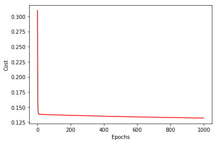

```python
model_five = FiveLP(**params)
model_five.fit(X_train_scaled_coded, y_train, print_progress=50)

yhat_5 = model_five.predict(X_test_scaled_coded)
print('Accuracy:', accuracy_score(np.argmax(y_test, axis=1), yhat_5))

cost_avgs = [np.mean(x) for x in model_five.cost_]

plt.plot(range(len(cost_avgs)), cost_avgs, color='red')
plt.ylabel('Cost')
plt.xlabel('Epochs')
plt.tight_layout()
```

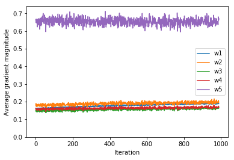

```python
ax = plt.subplot(1, 1, 1)
plt.plot(np.absolute(model_five.grad_w1_[10:]), label='w1')
plt.plot(np.absolute(model_five.grad_w2_[10:]), label='w2')
plt.plot(np.absolute(model_five.grad_w3_[10:]), label='w3')
plt.plot(np.absolute(model_five.grad_w4_[10:]), label='w4')
plt.plot(np.absolute(model_five.grad_w5_[10:]), label='w5')
plt.legend()
plt.ylim(0)
plt.ylabel('Average gradient magnitude')
plt.xlabel('Iteration')
plt.show()
```

```python
M = mn_test(yhat_5, yhat_4, np.argmax(y_test, axis=1))
print(f'Five layer vs Four layer: Test statistic = {M}.')
```

```
Five layer vs Four layer: Test statistic = 2.008298755186722.
```

| Layer | 2 | 3 | 4 | 5 |
| --- | --- | --- | --- | --- |
| Accuracy | 71.71% | 72.76% | 73.05% | 72.89% |

**With Five layer perceptron, the accuracy is around 72.89%, since the $\chi^2$ statistic value is even smaller than 2.706, we can conclude that there is no difference between four layer and five layer models.**

### 3.4 Five-layer Perceptron with AdaGrad

```python
class FiveLP_AdaGrad():
    def __init__(self, n_hidden=30, C=0.0, epochs=500, eta=0.001, random_state=None,
                 alpha=0.1, decrease_const=0.0, shuffle=True, minibatches=1):
        np.random.seed(random_state)
        self.n_hidden = n_hidden
        self.l2_C = C
        self.epochs = epochs
        self.eta = eta
        self.alpha = alpha
        self.decrease_const = decrease_const
        self.shuffle = shuffle
        self.minibatches = minibatches

    def _initialize_weights(self):
        init_bound = 4 * np.sqrt(6 / (self.n_hidden + self.n_features_ + 1))
        W1 = np.random.uniform(-init_bound, init_bound,
                               (self.n_hidden, self.n_features_ + 1))
        W1[:, :1] = 0

        init_bound = 4 * np.sqrt(6 / (self.n_hidden + self.n_hidden + 1))
        W2 = np.random.uniform(-init_bound, init_bound,
                               (self.n_hidden, self.n_hidden + 1))
        W2[:, :1] = 0

        init_bound = 4 * np.sqrt(6 / (self.n_hidden + self.n_hidden + 1))
        W3 = np.random.uniform(-init_bound, init_bound,
                               (self.n_hidden, self.n_hidden + 1))
        W3[:, :1] = 0

        init_bound = 4 * np.sqrt(6 / (self.n_hidden + self.n_hidden + 1))
        W4 = np.random.uniform(-init_bound, init_bound,
                               (self.n_hidden, self.n_hidden + 1))
        W4[:, :1] = 0

        init_bound = 4 * np.sqrt(6 / (self.n_output_ + self.n_hidden + 1))
        W5 = np.random.uniform(-init_bound, init_bound,
                               (self.n_output_, self.n_hidden + 1))
        W5[:, :1] = 0

        return W1, W2, W3, W4, W5

    @staticmethod
    def _sigmoid(z):
        return expit(z)

    @staticmethod
    def _add_bias_unit(X, how='column'):
        if how == 'column':
            ones = np.ones((X.shape[0], 1))
            X_new = np.hstack((ones, X))
        elif how == 'row':
            ones = np.ones((1, X.shape[1]))
            X_new = np.vstack((ones, X))

        return X_new

    @staticmethod
    def _L2_reg(lambda_, W1, W2, W3, W4, W5):
        return (lambda_/2.0) * np.sqrt(np.mean(W1[:, 1:] ** 2) + np.mean(W2[:, 1:] ** 2) + np.mean(W3[:, 1:] ** 2) + np.mean(W4[:, 1:] ** 2) + np.mean(W5[:, 1:] ** 2))

    def _cost(self, A6, Y_enc, W1, W2, W3, W4, W5):
        cost = np.mean((Y_enc-A6)**2)
        L2_term = self._L2_reg(self.l2_C, W1, W2, W3, W4, W5)

        return cost + L2_term

    def _feedforward(self, X, W1, W2, W3, W4, W5):
        A1 = self._add_bias_unit(X.T, how='row')
        Z1 = W1 @ A1
        A2 = self._sigmoid(Z1)
        A2 = self._add_bias_unit(A2, how='row')
        Z2 = W2 @ A2
        A3 = self._sigmoid(Z2)
        A3 = self._add_bias_unit(A3, how='row')
        Z3 = W3 @ A3
        A4 = self._sigmoid(Z3)
        A4 = self._add_bias_unit(A4, how='row')
        Z4 = W4 @ A4
        A5 = self._sigmoid(Z4)  # !added
        A5 = self._add_bias_unit(A5, how='row')
        Z5 = W5 @ A5
        A6 = self._sigmoid(Z5)

        return A1, Z1, A2, Z2, A3, Z3, A4, Z4, A5, Z5, A6

    def _get_gradient(self, A1, A2, A3, A4, A5, A6, Z1, Z2, Z3, Z4, Z5, Y_enc, W1, W2, W3, W4, W5):
        V5 = -2*(Y_enc-A6)*A6*(1-A6)
        V4 = A5*(1-A5)*(W5.T @ V5)
        V3 = A4*(1-A4)*(W4.T @ V4[1:, :])
        V2 = A3*(1-A3)*(W3.T @ V3[1:, :])
        V1 = A2*(1-A2)*(W2.T @ V2[1:, :])

        grad5 = V5 @ A5.T
        grad4 = V4[1:, :] @ A4.T
        grad3 = V3[1:, :] @ A3.T
        grad2 = V2[1:, :] @ A2.T
        grad1 = V1[1:, :] @ A1.T

        grad1[:, 1:] += W1[:, 1:] * self.l2_C
        grad2[:, 1:] += W2[:, 1:] * self.l2_C
        grad3[:, 1:] += W3[:, 1:] * self.l2_C
        grad4[:, 1:] += W4[:, 1:] * self.l2_C
        grad5[:, 1:] += W5[:, 1:] * self.l2_C

        return grad1, grad2, grad3, grad4, grad5

    def predict(self, X):
        _, _, _, _, _, _, _, _, _, _, A6 = self._feedforward(
            X, self.W1, self.W2, self.W3, self.W4, self.W5)
        y_pred = np.argmax(A6, axis=0)
        return y_pred

    def fit(self, X, y, print_progress=0):
        X_data, y_data = X.copy(), y.copy()
        Y_enc = np.transpose(y)
        print("Y_enc", Y_enc.shape)

        self.n_features_ = X_data.shape[1]
        self.n_output_ = Y_enc.shape[0]
        print("self.n_output_", self.n_output_)
        self.W1, self.W2, self.W3, self.W4, self.W5 = self._initialize_weights()  # !added

        G_w1 = np.zeros(self.W1.shape)
        G_w2 = np.zeros(self.W2.shape)
        G_w3 = np.zeros(self.W3.shape)
        G_w4 = np.zeros(self.W4.shape)
        G_w5 = np.zeros(self.W5.shape)
        self.grad_w1_, self.grad_w2_, self.grad_w3_, self.grad_w4_, self.grad_w5_ = [], [], [], [], []
        self.cost_ = []

        for k in range(self.epochs):
            if print_progress > 0 and (k+1) % print_progress == 0:
                sys.stderr.write('\rEpoch: %d/%d' % (k+1, self.epochs))
                sys.stderr.flush()

            if self.shuffle:
                ridx = np.random.permutation(y_data.shape[0])
                X_data, Y_enc = X_data[ridx], Y_enc[:, ridx]

            mini = np.array_split(range(y_data.shape[0]), self.minibatches)
            mini_cost = []

            grad1s, grad2s, grad3s, grad4s, grad5s = [], [], [], [], []
            for idx in mini:
                A1, Z1, A2, Z2, A3, Z3, A4, Z4, A5, Z5, A6 = self._feedforward(
                    X_data[idx], self.W1, self.W2, self.W3, self.W4, self.W5)
                cost = self._cost(
                    A6, Y_enc[:, idx], self.W1, self.W2, self.W3, self.W4, self.W5)
                mini_cost.append(cost)

                grad1, grad2, grad3, grad4, grad5 = self._get_gradient(
                    A1=A1, A2=A2, A3=A3, A4=A4, A5=A5, A6=A6, Z1=Z1, Z2=Z2, Z3=Z3, Z4=Z4, Z5=Z5,
                    Y_enc=Y_enc[:, idx], W1=self.W1, W2=self.W2, W3=self.W3, W4=self.W4, W5=self.W5)
                grad1s.append(np.mean(np.abs(grad1)))
                grad2s.append(np.mean(np.abs(grad2)))
                grad3s.append(np.mean(np.abs(grad3)))
                grad4s.append(np.mean(np.abs(grad4)))
                grad5s.append(np.mean(np.abs(grad5)))

                G_w1 += grad1 * grad1
                G_w2 += grad2 * grad2
                G_w3 += grad3 * grad3
                G_w4 += grad4 * grad4
                G_w5 += grad5 * grad5

                self.W1 -= self.eta * grad1 / np.sqrt(G_w1 + 1e-8)
                self.W2 -= self.eta * grad2 / np.sqrt(G_w2 + 1e-8)
                self.W3 -= self.eta * grad3 / np.sqrt(G_w3 + 1e-8)
                self.W4 -= self.eta * grad4 / np.sqrt(G_w4 + 1e-8)
                self.W5 -= self.eta * grad5 / np.sqrt(G_w5 + 1e-8)

            self.grad_w1_.append(np.mean(np.abs(grad1s)))
            self.grad_w2_.append(np.mean(np.abs(grad2s)))
            self.grad_w3_.append(np.mean(np.abs(grad3s)))
            self.grad_w4_.append(np.mean(np.abs(grad4s)))
            self.grad_w5_.append(np.mean(np.abs(grad5s)))
            self.cost_.append(mini_cost)
        return self
```

```
Y_enc (4, 58174)
self.n_output_ 4
```

```
Epoch: 1000/1000
```

```
Accuracy: 0.7297854785478548
```

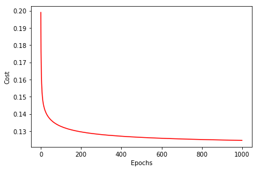

```python
model_AdaGrad = FiveLP_AdaGrad(**params)
model_AdaGrad.fit(X_train_scaled_coded, y_train, print_progress=50)

yhat_5_AdaGrad = model_AdaGrad.predict(X_test_scaled_coded)
print('Accuracy:', accuracy_score(np.argmax(y_test, axis=1), yhat_5_AdaGrad))

cost_avgs = [np.mean(x) for x in model_AdaGrad.cost_]

plt.plot(range(len(cost_avgs)), cost_avgs, color='red')
plt.ylabel('Cost')
plt.xlabel('Epochs')
plt.tight_layout()
```

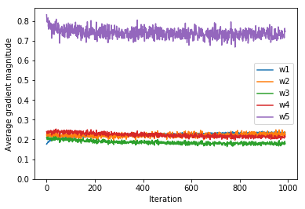

```python
ax = plt.subplot(1, 1, 1)
plt.plot(np.absolute(model_AdaGrad.grad_w1_[10:]), label='w1')
plt.plot(np.absolute(model_AdaGrad.grad_w2_[10:]), label='w2')
plt.plot(np.absolute(model_AdaGrad.grad_w3_[10:]), label='w3')
plt.plot(np.absolute(model_AdaGrad.grad_w4_[10:]), label='w4')
plt.plot(np.absolute(model_AdaGrad.grad_w5_[10:]), label='w5')
plt.legend()
plt.ylim(0)
plt.ylabel('Average gradient magnitude')
plt.xlabel('Iteration')
plt.show()
```

```python
M = mn_test(yhat_5, yhat_5_AdaGrad, np.argmax(y_test, axis=1))
print(f'Model without vs Model with AdaGrad: Test statistic = {M}.')
```

```
Model without vs Model with AdaGrad: Test statistic = 0.3538083538083538.
```

[output not shown]

**$\chi^2$ statistic value is even smaller than 2.706, the model with AdaGrad has the same performance with the one without AdaGrad.**

**The gradient vanishing issue also get better, the first four layers have similar gradient magnitude.**

## 4. Exceptional Work

```python
class FiveLP_AdaM():
    def __init__(self, n_hidden=30, C=0.0, epochs=500, eta=0.001, random_state=None,
                 alpha=0.1, decrease_const=0.0, shuffle=True, minibatches=1):
        np.random.seed(random_state)
        self.n_hidden = n_hidden
        self.l2_C = C
        self.epochs = epochs
        self.eta = eta
        self.alpha = alpha
        self.decrease_const = decrease_const
        self.shuffle = shuffle
        self.minibatches = minibatches

    def _initialize_weights(self):
        init_bound = 4 * np.sqrt(6 / (self.n_hidden + self.n_features_ + 1))
        W1 = np.random.uniform(-init_bound, init_bound,
                               (self.n_hidden, self.n_features_ + 1))
        W1[:, :1] = 0

        init_bound = 4 * np.sqrt(6 / (self.n_hidden + self.n_hidden + 1))
        W2 = np.random.uniform(-init_bound, init_bound,
                               (self.n_hidden, self.n_hidden + 1))
        W2[:, :1] = 0

        init_bound = 4 * np.sqrt(6 / (self.n_hidden + self.n_hidden + 1))
        W3 = np.random.uniform(-init_bound, init_bound,
                               (self.n_hidden, self.n_hidden + 1))
        W3[:, :1] = 0

        init_bound = 4 * np.sqrt(6 / (self.n_hidden + self.n_hidden + 1))
        W4 = np.random.uniform(-init_bound, init_bound,
                               (self.n_hidden, self.n_hidden + 1))
        W4[:, :1] = 0

        init_bound = 4 * np.sqrt(6 / (self.n_output_ + self.n_hidden + 1))
        W5 = np.random.uniform(-init_bound, init_bound,
                               (self.n_output_, self.n_hidden + 1))
        W5[:, :1] = 0

        return W1, W2, W3, W4, W5

    @staticmethod
    def _sigmoid(z):
        return expit(z)

    @staticmethod
    def _add_bias_unit(X, how='column'):
        if how == 'column':
            ones = np.ones((X.shape[0], 1))
            X_new = np.hstack((ones, X))
        elif how == 'row':
            ones = np.ones((1, X.shape[1]))
            X_new = np.vstack((ones, X))
        return X_new

    @staticmethod
    def _L2_reg(lambda_, W1, W2, W3, W4, W5):
        return (lambda_/2.0) * np.sqrt(np.mean(W1[:, 1:] ** 2) + np.mean(W2[:, 1:] ** 2) + np.mean(W3[:, 1:] ** 2) + np.mean(W4[:, 1:] ** 2) + np.mean(W5[:, 1:] ** 2))

    def _cost(self, A6, Y_enc, W1, W2, W3, W4, W5):
        cost = np.mean((Y_enc-A6)**2)
        L2_term = self._L2_reg(self.l2_C, W1, W2, W3, W4, W5)
        return cost + L2_term

    def _feedforward(self, X, W1, W2, W3, W4, W5):
        A1 = self._add_bias_unit(X.T, how='row')
        Z1 = W1 @ A1
        A2 = self._sigmoid(Z1)
        A2 = self._add_bias_unit(A2, how='row')
        Z2 = W2 @ A2
        A3 = self._sigmoid(Z2)
        A3 = self._add_bias_unit(A3, how='row')
        Z3 = W3 @ A3
        A4 = self._sigmoid(Z3)
        A4 = self._add_bias_unit(A4, how='row')
        Z4 = W4 @ A4
        A5 = self._sigmoid(Z4)
        A5 = self._add_bias_unit(A5, how='row')
        Z5 = W5 @ A5
        A6 = self._sigmoid(Z5)
        return A1, Z1, A2, Z2, A3, Z3, A4, Z4, A5, Z5, A6

    def _get_gradient(self, A1, A2, A3, A4, A5, A6, Z1, Z2, Z3, Z4, Z5, Y_enc, W1, W2, W3, W4, W5):
        V5 = -2*(Y_enc-A6)*A6*(1-A6)
        V4 = A5*(1-A5)*(W5.T @ V5)
        V3 = A4*(1-A4)*(W4.T @ V4[1:, :])
        V2 = A3*(1-A3)*(W3.T @ V3[1:, :])
        V1 = A2*(1-A2)*(W2.T @ V2[1:, :])

        grad5 = V5 @ A5.T
        grad4 = V4[1:, :] @ A4.T
        grad3 = V3[1:, :] @ A3.T
        grad2 = V2[1:, :] @ A2.T
        grad1 = V1[1:, :] @ A1.T

        grad1[:, 1:] += W1[:, 1:] * self.l2_C
        grad2[:, 1:] += W2[:, 1:] * self.l2_C
        grad3[:, 1:] += W3[:, 1:] * self.l2_C
        grad4[:, 1:] += W4[:, 1:] * self.l2_C
        grad5[:, 1:] += W5[:, 1:] * self.l2_C

        return grad1, grad2, grad3, grad4, grad5

    def predict(self, X):
        _, _, _, _, _, _, _, _, _, _, A6 = self._feedforward(
            X, self.W1, self.W2, self.W3, self.W4, self.W5)
        y_pred = np.argmax(A6, axis=0)

        return y_pred

    def fit(self, X, y, print_progress=0):
        X_data, y_data = X.copy(), y.copy()
        Y_enc = np.transpose(y)

        self.n_features_ = X_data.shape[1]
        self.n_output_ = Y_enc.shape[0]

        self.W1, self.W2, self.W3, self.W4, self.W5 = self._initialize_weights()

        beta_1, beta_2 = 0.9, 0.999
        M_w1, M_w2, M_w3, M_w4, M_w5 = np.zeros(self.W1.shape), np.zeros(self.W2.shape), np.zeros(
            self.W3.shape), np.zeros(self.W4.shape), np.zeros(self.W5.shape)
        V_w1, V_w2, V_w3, V_w4, V_w5 = np.zeros(self.W1.shape), np.zeros(self.W2.shape), np.zeros(
            self.W3.shape), np.zeros(self.W4.shape), np.zeros(self.W5.shape)
        self.grad_w1_, self.grad_w2_, self.grad_w3_, self.grad_w4_, self.grad_w5_ = [], [], [], [], []
        self.cost_ = []

        t = 0
        for k in range(self.epochs):
            if print_progress > 0 and (k+1) % print_progress == 0:
                sys.stderr.write('\rEpoch: %d/%d' % (k+1, self.epochs))
                sys.stderr.flush()

            if self.shuffle:
                ridx = np.random.permutation(y_data.shape[0])
                X_data, Y_enc = X_data[ridx], Y_enc[:, ridx]

            mini = np.array_split(range(y_data.shape[0]), self.minibatches)
            mini_cost = []
            grad1s, grad2s, grad3s, grad4s, grad5s = [], [], [], [], []

            for idx in mini:
                t += 1
                A1, Z1, A2, Z2, A3, Z3, A4, Z4, A5, Z5, A6 = self._feedforward(
                    X_data[idx], self.W1, self.W2, self.W3, self.W4, self.W5)
                cost = self._cost(
                    A6, Y_enc[:, idx], self.W1, self.W2, self.W3, self.W4, self.W5)
                mini_cost.append(cost)
                grad1, grad2, grad3, grad4, grad5 = self._get_gradient(
                    A1=A1, A2=A2, A3=A3, A4=A4, A5=A5, A6=A6, Z1=Z1, Z2=Z2, Z3=Z3, Z4=Z4, Z5=Z5,
                    Y_enc=Y_enc[:, idx], W1=self.W1, W2=self.W2, W3=self.W3, W4=self.W4, W5=self.W5)
                grad1s.append(np.mean(np.abs(grad1)))
                grad2s.append(np.mean(np.abs(grad2)))
                grad3s.append(np.mean(np.abs(grad3)))
                grad4s.append(np.mean(np.abs(grad4)))
                grad5s.append(np.mean(np.abs(grad5)))

                M_w1 = beta_1 * M_w1 + (1-beta_1) * grad1
                M_w2 = beta_1 * M_w2 + (1-beta_1) * grad2
                M_w3 = beta_1 * M_w3 + (1-beta_1) * grad3
                M_w4 = beta_1 * M_w4 + (1-beta_1) * grad4
                M_w5 = beta_1 * M_w5 + (1-beta_1) * grad5

                V_w1 = beta_2 * V_w1 + (1-beta_2) * grad1 * grad1
                V_w2 = beta_2 * V_w2 + (1-beta_2) * grad2 * grad2
                V_w3 = beta_2 * V_w3 + (1-beta_2) * grad3 * grad3
                V_w4 = beta_2 * V_w4 + (1-beta_2) * grad4 * grad4
                V_w5 = beta_2 * V_w5 + (1-beta_2) * grad5 * grad5

                M_w1_hat = M_w1 / (1 - beta_1 ** t)
                M_w2_hat = M_w2 / (1 - beta_1 ** t)
                M_w3_hat = M_w3 / (1 - beta_1 ** t)
                M_w4_hat = M_w4 / (1 - beta_1 ** t)
                M_w5_hat = M_w5 / (1 - beta_1 ** t)

                V_w1_hat = V_w1 / (1 - beta_2 ** t)
                V_w2_hat = V_w2 / (1 - beta_2 ** t)
                V_w3_hat = V_w3 / (1 - beta_2 ** t)
                V_w4_hat = V_w4 / (1 - beta_2 ** t)
                V_w5_hat = V_w5 / (1 - beta_2 ** t)

                self.W1 -= self.eta * M_w1_hat / np.sqrt(V_w1_hat + 1e-8)
                self.W2 -= self.eta * M_w2_hat / np.sqrt(V_w2_hat + 1e-8)
                self.W3 -= self.eta * M_w3_hat / np.sqrt(V_w3_hat + 1e-8)
                self.W4 -= self.eta * M_w4_hat / np.sqrt(V_w4_hat + 1e-8)
                self.W5 -= self.eta * M_w5_hat / np.sqrt(V_w5_hat + 1e-8)

            self.grad_w1_.append(np.mean(np.abs(grad1s)))
            self.grad_w2_.append(np.mean(np.abs(grad2s)))
            self.grad_w3_.append(np.mean(np.abs(grad3s)))
            self.grad_w4_.append(np.mean(np.abs(grad4s)))
            self.grad_w5_.append(np.mean(np.abs(grad5s)))
            self.cost_.append(mini_cost)
        return self
```

```
Epoch: 1000/1000
```

```
Accuracy: 0.7147964796479648
```

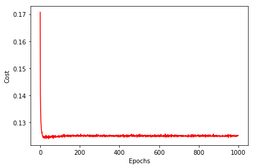

```python
model_AdaM = FiveLP_AdaM(**params)
model_AdaM.fit(X_train_scaled_coded, y_train, print_progress=50)

yhat_5_AdaM = model_AdaM.predict(X_test_scaled_coded)
print('Accuracy:', accuracy_score(np.argmax(y_test, axis=1), yhat_5_AdaM))

cost_avgs = [np.mean(x) for x in model_AdaM.cost_]

plt.plot(range(len(cost_avgs)), cost_avgs, color='red')
plt.ylabel('Cost')
plt.xlabel('Epochs')
plt.tight_layout()
```

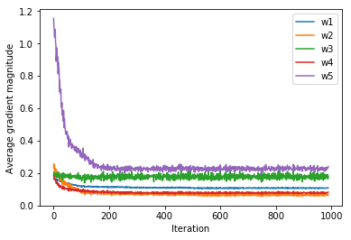

```python
ax = plt.subplot(1, 1, 1)
plt.plot(np.absolute(model_AdaM.grad_w1_[10:]), label='w1')
plt.plot(np.absolute(model_AdaM.grad_w2_[10:]), label='w2')
plt.plot(np.absolute(model_AdaM.grad_w3_[10:]), label='w3')
plt.plot(np.absolute(model_AdaM.grad_w4_[10:]), label='w4')
plt.plot(np.absolute(model_AdaM.grad_w5_[10:]), label='w5')
plt.legend()
plt.ylim(0)
plt.ylabel('Average gradient magnitude')
plt.xlabel('Iteration')
plt.show()
```

```python
M = mn_test(yhat_5, yhat_5_AdaM, np.argmax(y_test, axis=1))
print(f'Five layer with AdaM vs Five layer: Test statistic = {M}.')
M = mn_test(yhat_5_AdaGrad, yhat_5_AdaM, np.argmax(y_test, axis=1))
print(f'Five layer with AdaM vs Five layer with AdaGrad: Test statistic = {M}.')
```

```
Five layer with AdaM vs Five layer: Test statistic = 29.041172365666434.
Five layer with AdaM vs Five layer with AdaGrad: Test statistic = 30.979605263157893.
```

**With AdaM, we get accuracy 71.48%, according to the $\chi^2$ statistic value, five layer and five layer with AdaGrad are better than five layer with AdaM. However, with AdaM, the gradient vanishing issue get better resolved, and the model converges faster than five layers perceptron with AdaGrad.**

##### AdaM with recommended learning rate 0.001

```python
params['eta'] = 0.001

model_AdaM_2 = FiveLP_AdaM(**params)
model_AdaM_2.fit(X_train_scaled_coded, y_train, print_progress=50)
```

```
Epoch: 1000/1000
```

```
<__main__.FiveLP_AdaM at 0x2aab27de3cc0>
```

```
Accuracy: 0.7310918591859186
```

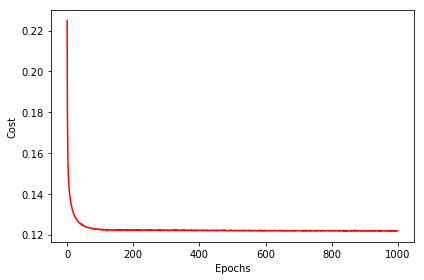

```python
yhat_5_AdaM2 = model_AdaM_2.predict(X_test_scaled_coded)
print('Accuracy:', accuracy_score(np.argmax(y_test, axis=1), yhat_5_AdaM2))

cost_avgs = [np.mean(x) for x in model_AdaM_2.cost_]

plt.plot(range(len(cost_avgs)), cost_avgs, color='red')
plt.ylabel('Cost')
plt.xlabel('Epochs')
plt.tight_layout()
```

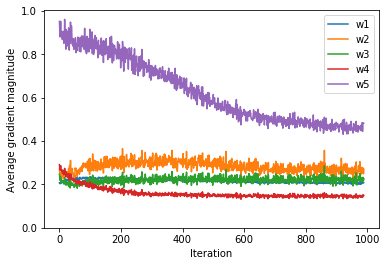

```python
ax = plt.subplot(1, 1, 1)
plt.plot(np.absolute(model_AdaM_2.grad_w1_[10:]), label='w1')
plt.plot(np.absolute(model_AdaM_2.grad_w2_[10:]), label='w2')
plt.plot(np.absolute(model_AdaM_2.grad_w3_[10:]), label='w3')
plt.plot(np.absolute(model_AdaM_2.grad_w4_[10:]), label='w4')
plt.plot(np.absolute(model_AdaM_2.grad_w5_[10:]), label='w5')
plt.legend()
plt.ylim(0)
plt.ylabel('Average gradient magnitude')
plt.xlabel('Iteration')
plt.show()
```

```python
M = mn_test(yhat_5, yhat_5_AdaM2, np.argmax(y_test, axis=1))
print(f'Five layer with AdaM vs Five layer: Test statistic = {M}.')
M = mn_test(yhat_5_AdaGrad, yhat_5_AdaM2, np.argmax(y_test, axis=1))
print(f'Five layer with AdaM vs Five layer with AdaGrad: Test statistic = {M}.')
```

```
Five layer with AdaM vs Five layer: Test statistic = 1.3273480662983426.
Five layer with AdaM vs Five layer with AdaGrad: Test statistic = 0.6492985971943888.
```

[output not shown]

**With recommonded learing rate 0.001, five layer with AdaM get the best accuracy 73.11%, although according to $\chi^2$ statistic value, there is no significant differences with five layer or five layer with AdaGrad.**

## 5. Further thoughts

- **We can further implement ReLU as activation functions**
- **We can add parameters to set hidden layers with differnt sizes**